# mid_exam

b06208016楊鎧綾

October 17, 2018

# 1

## (1)

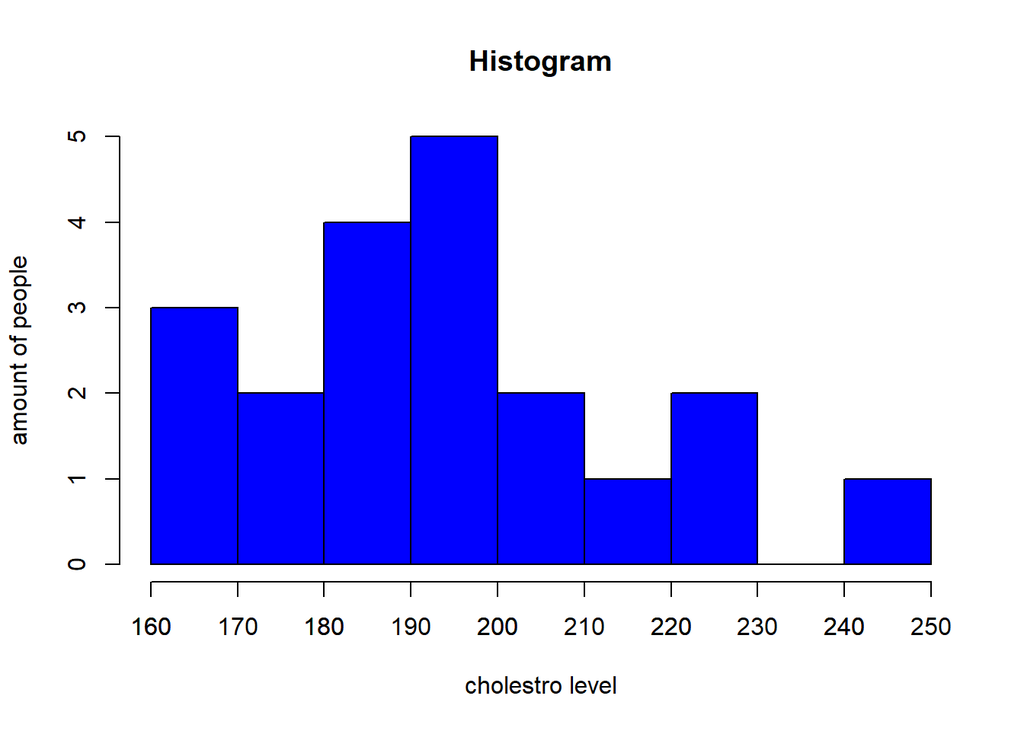

```r
cho=c(196,198,212,182,200,222,249,198,206,188,178,166,184,204,198,178,160,164,182,230)
hist(cho,col="blue",breaks = 10, main="Histogram", xlab="cholestro level",ylab = "amount of people")
axis(side = 1, at = seq(160,250,by=10))
```

**as the histogram show**

## (2)

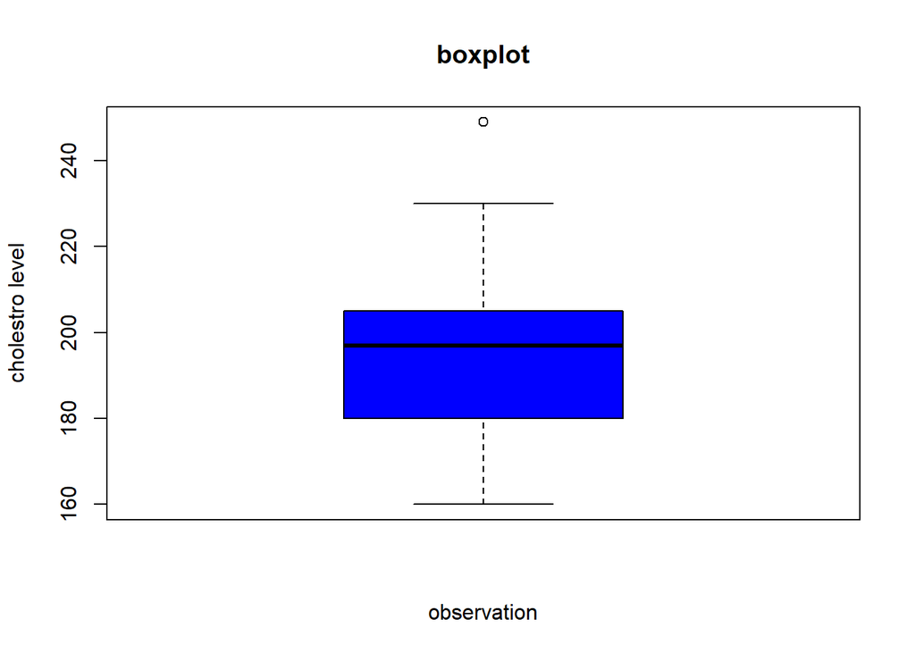

```r
boxplot(cho, col="blue", main="boxplot", xlab="observation", ylab="cholestro level" )
```

**as the boxplot show**

## (3)

```r
MyOutlierDetect<-function(x,value){
  s<-quantile(x,na.rm = TRUE)
  IQR<-IQR(x,na.rm = TRUE)
  min<-s[[2]]-1.5*IQR
  max<-s[[4]]+1.5*IQR
  if(value>=min & value<=max){
    return("NO")
  }else{
    return("YES")
  }

}

out=c()
for (i in 1:20){
out[i]=MyOutlierDetect(cho,cho[i])
}
out
```

```
##  [1] "NO"  "NO"  "NO"  "NO"  "NO"  "NO"  "YES" "NO"  "NO"  "NO"  "NO"
## [12] "NO"  "NO"  "NO"  "NO"  "NO"  "NO"  "NO"  "NO"  "NO"
```

```r
cho[out=="YES"]
```

```
## [1] 249
```

**249 is a outlier**

## (4)

```r
summary(cho)
```

```
##    Min. 1st Qu.  Median    Mean 3rd Qu.    Max.
##   160.0   181.0   197.0   194.8   204.5   249.0
```

**min=160.0；$q_{1}$=181.0；median=197.0；$q_{3}$=204.5；max=249.0**

## (5)

**由barplot來看此圖型為skewed-right；由five-number summary來看$q_{1}$-min=21,max-$q_{3}$=44.5，可以確定此分布為右偏**

# 2

註:table A 的方式皆為標準化後進行查表

## (1)

### code

P(62<=X<=65)=P(X<=65)-P(X<62)

```r
mean=65
sd=2.7
pnorm(65,mean,sd)-pnorm(62,mean,sd)
```

```
## [1] 0.3667397
```

### table A

```r
a=(62-mean)/sd
a
```

```
## [1] -1.111111
```

```r
b=(65-mean)/sd
b
```

```
## [1] 0
```

經由查表  
P(z<(-1.11))=0.1335  
P(z<0)=0.5  
所求為  
P(z<0)-P(z<(-1.11))=0.3665

```r
0.5-0.1335
```

```
## [1] 0.3665
```

**code:0.3667397,table A:0.3665**

## (2)

### code

P(X<70)

```r
pnorm(70,mean,sd)
```

```
## [1] 0.9679765
```

### table A

```r
c=(70-mean)/sd
c
```

```
## [1] 1.851852
```

經由查表  
P(z<1.85)=0.9678  
**code:0.9679765；table A:0.9678**

## (3)

### CODE

```r
1-pnorm(60,mean,sd)
```

```
## [1] 0.9679765
```

### table A

```r
d=(60-mean)/sd
d
```

```
## [1] -1.851852
```

經由查表  
P(z<(-1.85))=0.0322  
所求為  
1-P(z<(-1.85))=0.9678  
**code:0.9679765；table A:0.9678**

## (4)

### code

P(X>70) or P(X<60)，因為兩者互斥，所以機率為P(X<60)+P(X>70)

```r
pnorm(60,mean,sd)+(1-pnorm(70,mean,sd))
```

```
## [1] 0.0640471
```

### table A

經由查表  
P(X<=60):P(z<(-1.85))=0.0322  
P(X<=70):P(z<1.85)=0.9678  
所求為  
P(X>70)+P(X<=60)

```r
(1-0.9678)+0.0322
```

```
## [1] 0.0644
```

**code:0.0640471；table A:0.0644**

# 3

## (1)

假設A為代表泛藍選民的事件  
已知  
P(A)=0.6  
P(AC)=0.4  
求P(KP)  
P(KP|A)=0.4  
P(KP|AC)=0.5  
P(KP)=P(A)P(KP|A)+P(AC)P(KP|AC)=0.44

```r
0.6*0.4+0.4*0.5
```

```
## [1] 0.44
```

求P(DD)  
P(DD|A)=0.55  
P(DD|AC)=0.05  
P(DD)=P(A)P(DD|A)+P(AC)P(DD|AC)=0.35

```r
0.6*0.55+0.4*0.05
```

```
## [1] 0.35
```

求P(YY)  
P(YY|A)=0.05  
P(YY|AC)=0.45  
P(YY)=P(A)P(YY|A)+P(AC)P(YY|AC)=0.21

```r
0.6*0.05+0.4*0.45
```

```
## [1] 0.21
```

**估計KP,DD,YY各自的得票率為44%,35%,21%**

## (2)

假設YY要提高X的支持率  
KP=0.24+0.4(0.5-X)=0.44-0.4X  
YY=0.03+0.4(0.45+X)=0.21+0.4X  
0.44-0.4X<0.21+0.4X  
0.23<0.8X  
X>(23/80)

```r
23/80
```

```
## [1] 0.2875
```

**要提高28.75%以上非泛藍選民對YY的支持度**

# 4

## (1)

```r
(0.9*0.1)/((0.9*0.1)+(0.1*0.8))
```

```
## [1] 0.5294118
```

**在起點機場起飛誤點的情況下，在終點機場準時抵達的機率為0.5294118**

## (2)

```r
p=(0.2*0.1)/((0.2*0.1)+(0.9*0.9))
200*p*100
```

```
## [1] 481.9277
```

p為飛機準時出發但在終點機場誤點的機率，即P(A|BC)=P(A and BC)/P(BC)  
200*p為估計此生會發生飛機準時出發但在終點機場誤點的期望值，再將此乘以100美元，即為預計此生可得賠償金額的期望值  
**481.9277美元**

# 5

## (1)

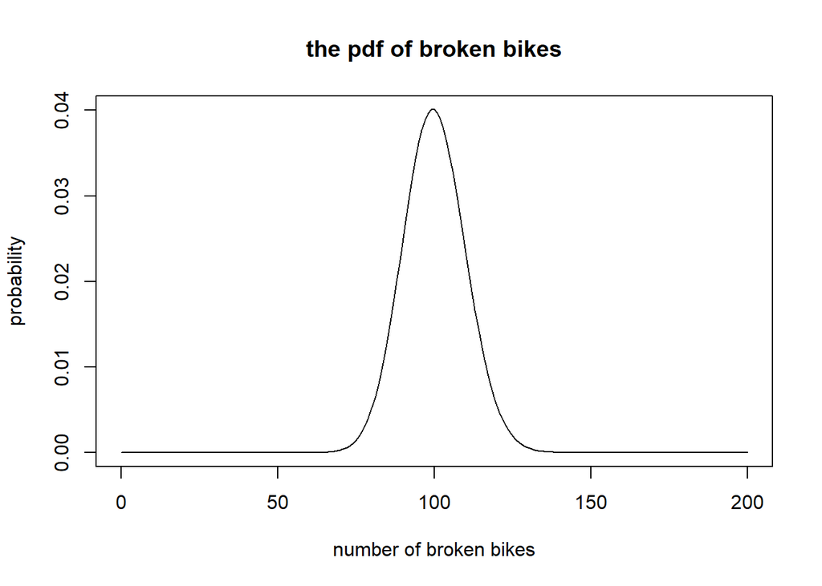

```r
xvalue<-seq(0, 200,length.out =  201)
yvalue<-dbinom(xvalue, size=10000, prob=0.01)
plot(xvalue, yvalue, main="the pdf of broken bikes", type="l",xlab="number of broken bikes",ylab="probability")
```

## (2)

```r
1-pbinom(120,400,0.25)
```

```
## [1] 0.009970218
```

**每天有超過30%的租借站出現故障車的機率為0.009970218**

## (3)

```r
mutate<-rbinom(365,10000,0.01)
```

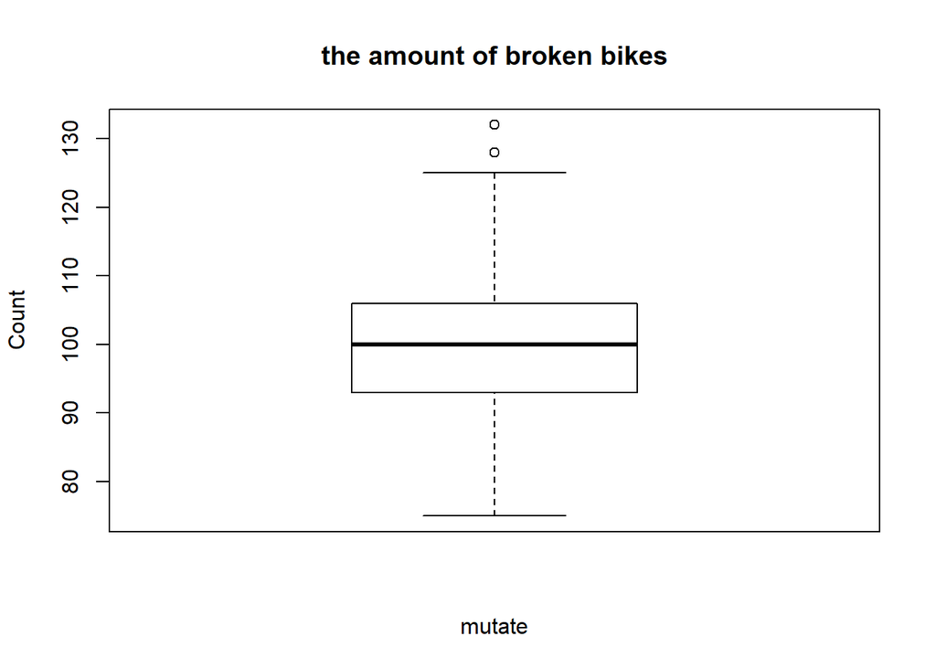

```r
#利用boxplot 觀察
boxplot(mutate, main="the amount of broken bikes", xlab="mutate", ylab="Count" )
```

```r
MyOutlierDetect<-function(x,value){
  s<-quantile(x,na.rm = TRUE)
  IQR<-IQR(x,na.rm = TRUE)
  min<-s[[2]]-1.5*IQR
  max<-s[[4]]+1.5*IQR
  if(value>=min & value<=max){
    return("NO")
  }else{
    return("YES")
  }

}
```

```r
is.out<-c()
for(i in 1:365){
  is.out[i]<-MyOutlierDetect(mutate,mutate[i])
}
length(is.out[is.out=="YES"])
```

```
## [1] 3
```

**the answer is as the code answer**